# Untitled

## Question 3.11 : Calculate Empirical Distribution Functions

```r
data("Phillies2009")


ls(Phillies2009) # looking at the available variables
```

```
## [1] "Date"       "Doubles"    "Hits"       "HomeRuns"   "Location"
## [6] "Outcome"    "StrikeOuts"
```

```r
home.game <- Phillies2009 %>%
  filter (Location == "Home")
home.game
```

```
##          Date Location Outcome Hits Doubles HomeRuns StrikeOuts
## 1       5-Apr     Home    Lose    4       2        0          6
## 2       7-Apr     Home    Lose    6       1        0          3
## 3       8-Apr     Home     Win   11       3        1          6
## 4      17-Apr     Home    Lose   14       3        1          5
## 5      18-Apr     Home    Lose    8       2        3          7
## 6      19-Apr     Home     Win    9       1        3          5
## 7      21-Apr     Home     Win   13       4        1          8
## 8      22-Apr     Home    Lose    8       0        1          4
## 9      23-Apr     Home    Lose    2       0        1          4
## 10     27-Apr     Home     Win   14       5        2          7
## 11     28-Apr     Home     Win   11       0        4          5
## 12     29-Apr     Home    Lose    7       0        1          8
## 13      1-May     Home    Lose    8       0        1          4
## 14      2-May     Home     Win    9       3        1          6
```

[output cut: 67 more lines]

```r
away.game <- Phillies2009 %>%
  filter (Location == "Away")
away.game
```

```
##          Date Location Outcome Hits Doubles HomeRuns StrikeOuts
## 1      10-Apr     Away    Lose    7       2        1          3
## 2      11-Apr     Away     Win   15       3        1          6
## 3      12-Apr     Away     Win   13       3        2          4
## 4      13-Apr     Away     Win   10       3        3          7
## 5      16-Apr     Away    Lose    5       1        0          3
## 6      24-Apr     Away     Win    8       2        2         12
## 7      25-Apr     Away     Win    9       0        2          8
## 8      26-Apr     Away     Win   12       2        0          7
## 9       4-May     Away     Win    8       1        2         11
## 10      5-May     Away     Win   15       4        2          7
## 11      6-May     Away    Lose    3       2        0         11
## 12      7-May     Away    Lose   10       2        2          0
## 13     15-May     Away     Win   16       1        1          9
## 14 May 16 (1)     Away     Win   14       2        3          5
```

[output cut: 67 more lines]

Created a histogram with facet options as suggested in class instead of doing ecdf.

From the histogram below, we can see that when location is away, the distribution of data seems to follow a normal distribution. Where as when we look at home data, there are multiple peaks and the distribution certianly doesnot look normal.

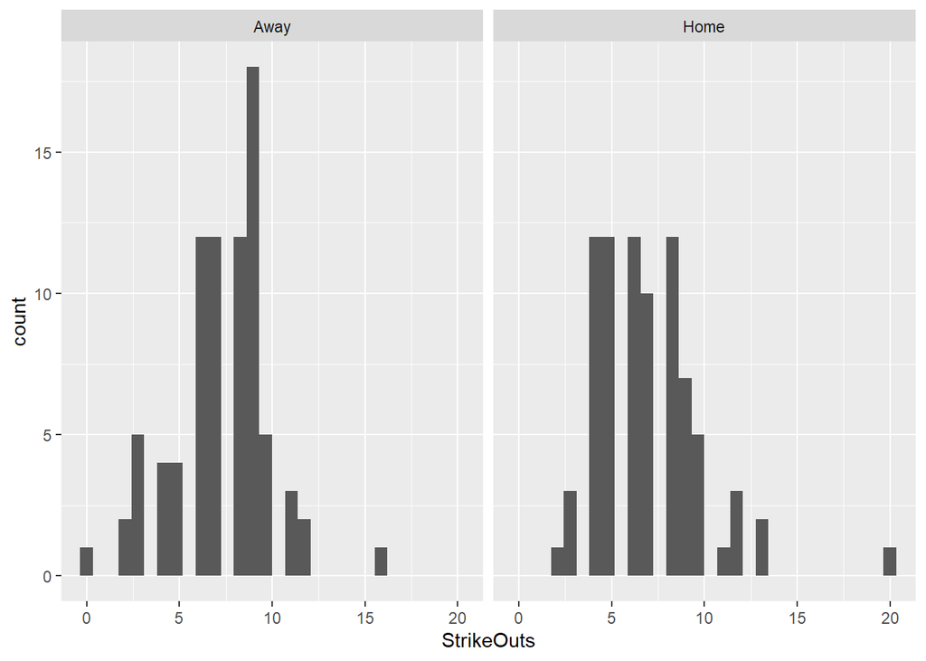

```r
ggplot(data=Phillies2009,mapping = aes(x= StrikeOuts)) +
  geom_histogram() +
  facet_wrap(~ Location)
```

```r
mean.home = mean((home.game$StrikeOuts), na.rm = TRUE)
mean.home
```

```
## [1] 6.950617
```

```r
away.home = mean((away.game$StrikeOuts), na.rm = TRUE)
away.home
```

```
## [1] 7.308642
```

```r
observed.home.away = mean.home - away.home
observed.home.away
```

```
## [1] -0.3580247
```

```r
#summarize (mean_late.UA = mean(Delay), na.rm = TRUE)
```

We can see that the mean number of strike out per game for the home is 6.95 and for the away games is 7.30. The observed difference is -0.3580

3. Calculate the permutation tests

```r
N <- 10^4 -1
sample.size.games = nrow(Phillies2009)

away.group1 = nrow(Phillies2009[Phillies2009$Location =="Away",])
#The no of sample is this group is 81 and the sample size is 162.

result.location <- numeric(N)

for (i in 1:N)
{
  index = sample(sample.size.games, size = away.group1, replace = FALSE)
  result.location[i] = mean(Phillies2009$StrikeOuts[index]) -       mean(Phillies2009$StrikeOuts[-index])
  }
```

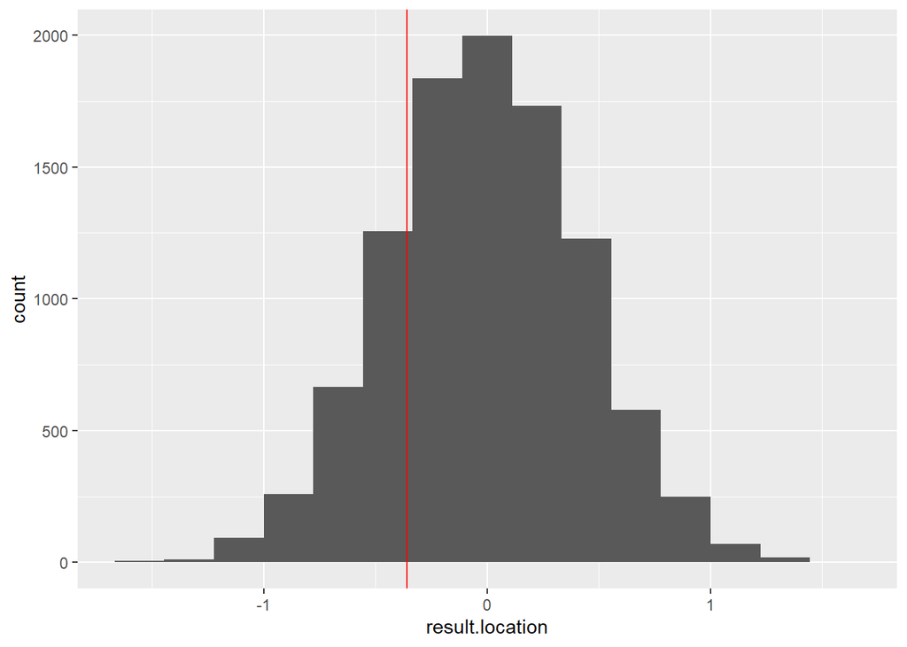

```r
ggplot(data=tibble(result.location), mapping = aes(x=result.location)) +
  geom_histogram(bins = 15) +
  geom_vline(xintercept = observed.home.away, color = "red")
```

```r
# Calculating the p value
p.value.away <- (sum(result.location <= observed.home.away) + 1) *2 / (N + 1)
p.value.away
```

```
## [1] 0.423
```

## Question no 3.14

```r
data("IceCream")

#View(IceCream)
```

The data set is a matched pair because brands make both chocolate and vanilla ice cream, which means that the taste, calorie of the ice cream could depend on the brands that make them. Therefore, it is not entirely independent.

```r
Vanilla <- summary(IceCream$VanillaCalories)
Chocolate <- summary(IceCream$ChocolateCalories)
Vanilla
```

```
##    Min. 1st Qu.  Median    Mean 3rd Qu.    Max.
##   120.0   140.0   160.0   191.4   240.0   307.0
```

```r
Chocolate
```

```
##    Min. 1st Qu.  Median    Mean 3rd Qu.    Max.
##   120.0   140.0   170.0   198.7   260.0   320.0
```

From the table above we can see that Vanilla calories has mean of 191.4 and median of 160. Chocolate has mean of 198.7 and median of 170.

```r
vanilla.mean = mean((IceCream$VanillaCalories), na.rm = TRUE)
chocolate.mean = mean((IceCream$ChocolateCalories), namrm = TRUE)
diff.ice.cal =  chocolate.mean - vanilla.mean
diff.ice.cal
```

```
## [1] 7.333333
```

The difference in mean of these calories is 7.33

```r
N <- 10^4 -1
result.calor.diff <- numeric(N)
samplesize.icecream = nrow(IceCream)

for ( i in 1: N)
{
  Sign <- sample (c(-1,1), samplesize.icecream, replace = TRUE)
  result.diff <- Sign * diff.ice.cal
  result.calor.diff[i] <- mean(result.diff)
}
```

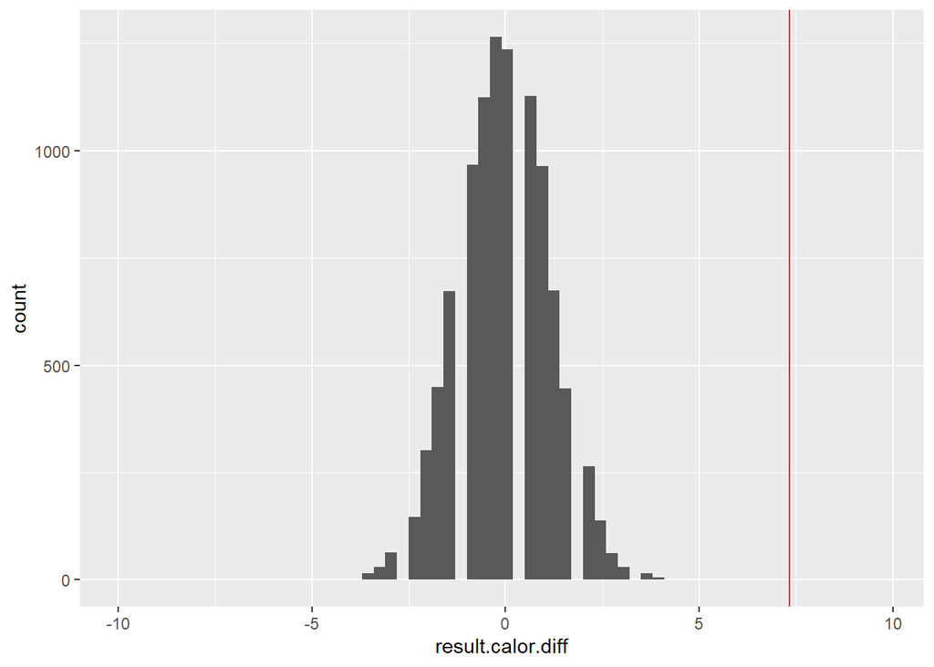

```r
ggplot(data=tibble(result.calor.diff), mapping =   aes(x=result.calor.diff)) +
  geom_histogram(breaks=seq(-10,10,by=0.3)) +
  geom_vline(xintercept = diff.ice.cal, color = "red")
```

```r
p.value.icecream <- (sum(result.calor.diff >= diff.ice.cal) + 1)  / (N + 1)
p.value.away
```

```
## [1] 0.423
```

## Question 3.15

```r
data("Groceries")

#view(Groceries)
```

It is a matched pair data because it is the same product that is being sold across different grocery chains so if a product is at baseline expensive, it will be on average expensive compared to other products throughout so we cannot treat these samples as a independent samples

```r
summary(Groceries$Target)
```

```
##    Min. 1st Qu.  Median    Mean 3rd Qu.    Max.
##   0.990   1.827   2.545   2.762   3.140   7.990
```

```r
summary(Groceries$Walmart)
```

```
##    Min. 1st Qu.  Median    Mean 3rd Qu.    Max.
##   1.000   1.760   2.340   2.706   2.955   6.980
```

From the summary above we can see that on average(mean) of the price on Target is 2.76 and of walmart is 2.706. The median is 2.340 is Walmart and it is 2.545 is Target. We can therefore, imply that the center srpead tends to be higher in Target compared to Walmart.

```r
walmart.mean = mean((Groceries$Walmart), na.rm = TRUE)
Target.mean = mean((Groceries$Target), namrm = TRUE)
diff.price =  walmart.mean- Target.mean
diff.price
```

```
## [1] -0.05666667
```

The difference in price is of 0.056, so mean price in target is higher by 0.0566

```r
N <- 10^4 -1
result.price.diff <- numeric(N)
samplesize.Groceries = nrow(Groceries)

for ( i in 1: N)
{
  Sign.price <- sample (c(-1,1), samplesize.Groceries, replace = TRUE)
  result.diff <- Sign.price * diff.price
  result.price.diff[i] <- mean(result.price.diff)
}
```

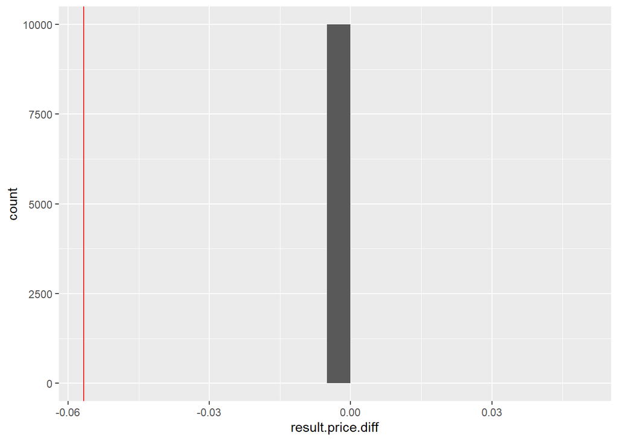

```r
ggplot(data=tibble(result.price.diff), mapping =   aes(x=result.price.diff)) +
  geom_histogram(breaks=seq(-0.05,0.05,by=0.005)) +
  geom_vline(xintercept = diff.price, color = "red")
```

The gap between in the histogram is incredibly difficult to break.

```r
p.value.price <- (sum(result.price.diff <= diff.price) + 1) *2 / (N + 1)
p.value.price
```

```
## [1] 2e-04
```

The p value is really small so we can reject the null that there us no difference between the mean prices.

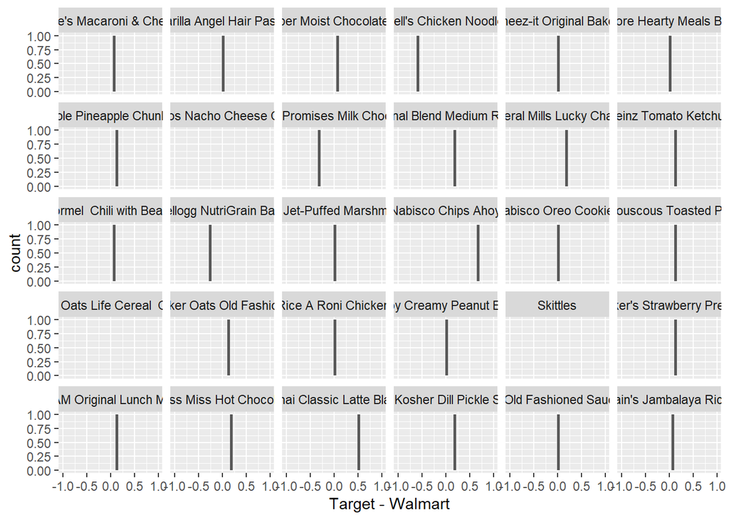

```r
#view(Groceries)

ggplot(data =Groceries, mapping = aes(x = Target - Walmart)) +
  geom_histogram(breaks=seq(-1, 1, by=0.055)) +
  facet_wrap(~ Product, nrow =5)
```

WE can see that there is significant difference in the price for Quacker oats, where in the price for quaker oats in Walmart is significantly higher in Walmart.Thugh it is hard to observe from graph, when we look at the dataset itself, we can see that Quacker oats is an exception,

```r
Groceries.final <-Groceries[!(Groceries$Product =="Quaker Oats Life Cereal  Original "),] #Removed the oats
view(Groceries.final)
```

```r
walmart.mean.f = mean((Groceries.final$Walmart), na.rm = TRUE)
Target.mean.f = mean((Groceries.final$Target), namrm = TRUE)
diff.price.f =  walmart.mean.f- Target.mean.f
diff.price.f
```

```
## [1] -0.1558621
```

The difference in price is of -0.1558, so mean price in target is higher by 0.15586

```r
N <- 10^4 -1
result.price.diff.f <- numeric(N)
samplesize.Groceries.final = nrow(Groceries.final)

for ( i in 1: N)
{
  Sign.price.f <- sample (c(-1,1), samplesize.Groceries.final, replace = TRUE)
  result.diff.f <- Sign.price * diff.price.f
  result.price.diff.f[i] <- mean(result.price.diff.f)
}
```

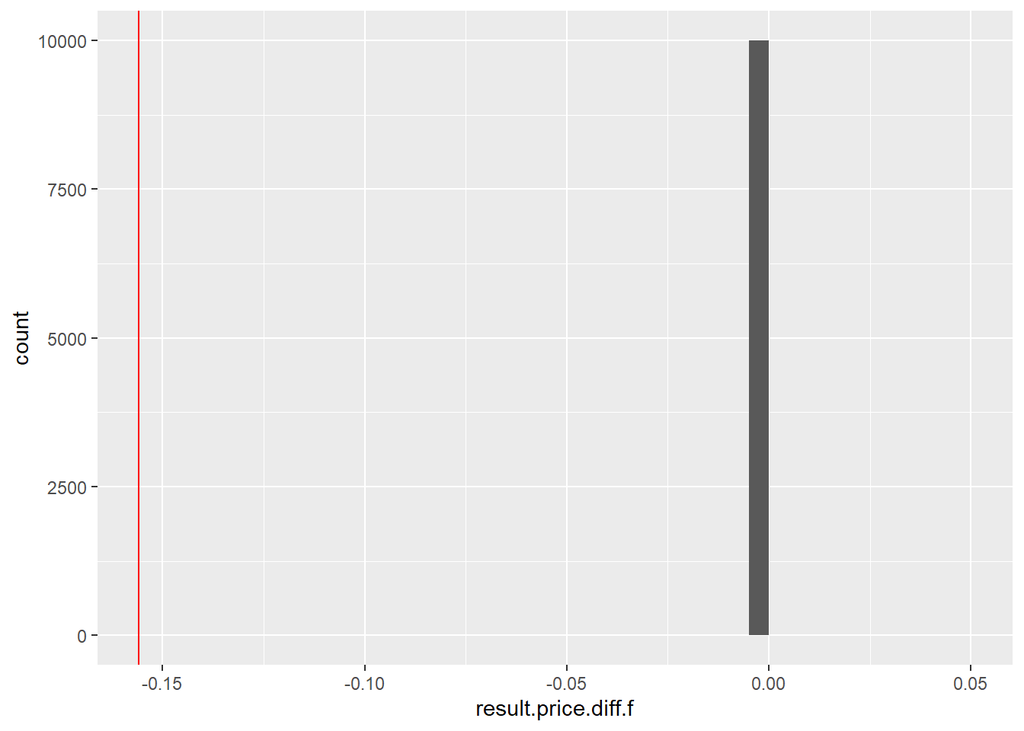

```r
ggplot(data=tibble(result.price.diff.f), mapping =   aes(x=result.price.diff.f)) +
  geom_histogram(breaks=seq(-0.05,0.05,by=0.005)) +
  geom_vline(xintercept = diff.price.f, color = "red")
```

```r
p.value.price <- (sum(result.price.diff <= diff.price) + 1) *2 / (N + 1)
p.value.price
```

```
## [1] 2e-04
```

```r
library(nycflights13)


delta_flights <- flights %>%
filter(carrier=="DL")
head(delta_flights, 10)
```

```
## # A tibble: 10 × 19
##     year month   day dep_time sched_de…¹ dep_d…² arr_t…³ sched…⁴ arr_d…⁵ carrier
##    <int> <int> <int>    <int>      <int>   <dbl>   <int>   <int>   <dbl> <chr>
##  1  2013     1     1      554        600      -6     812     837     -25 DL
##  2  2013     1     1      602        610      -8     812     820      -8 DL
##  3  2013     1     1      606        610      -4     837     845      -8 DL
##  4  2013     1     1      615        615       0     833     842      -9 DL
##  5  2013     1     1      653        700      -7     936    1009     -33 DL
##  6  2013     1     1      655        655       0    1021    1030      -9 DL
##  7  2013     1     1      655        700      -5    1037    1045      -8 DL
##  8  2013     1     1      655        700      -5    1002    1020     -18 DL
##  9  2013     1     1      657        700      -3     959    1013     -14 DL
## 10  2013     1     1      658        700      -2     944     939       5 DL
## # … with 9 more variables: flight <int>, tailnum <chr>, origin <chr>,
## #   dest <chr>, air_time <dbl>, distance <dbl>, hour <dbl>, minute <dbl>,
## #   time_hour <dttm>, and abbreviated variable names ¹sched_dep_time,
## #   ²dep_delay, ³arr_time, ⁴sched_arr_time, ⁵arr_delay
```

```r
delta_origin <- delta_flights%>%
  filter(origin == "EWR"| origin == "JFK" |origin == "LGA")
```

```r
summary_dep_delay <- delta_flights %>%
  group_by(origin) %>%
  summarize(mean = mean(dep_delay, na.rm = TRUE))
summary_dep_delay
```

```
## # A tibble: 3 × 2
##   origin  mean
##   <chr>  <dbl>
## 1 EWR    12.1
## 2 JFK     8.33
## 3 LGA     9.57
```

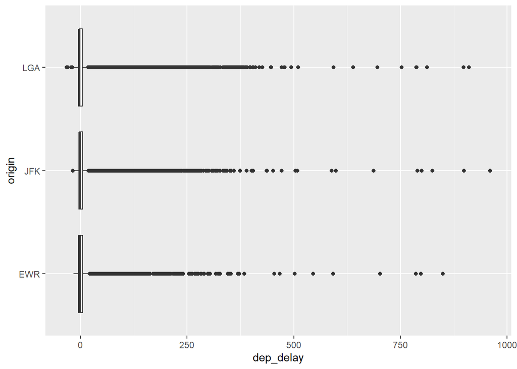

```r
ggplot(data = delta_flights, aes(x = dep_delay, y = origin)) +
  geom_boxplot()
```

From boxplot we can see that LGa also see that delay is concentrated across all origin flightd and all flights also have outliers.

```r
EWR <- delta_flights %>%
  filter (origin == "EWR")  %>%
  summarize(meanEWR = mean(delta_flights$dep_delay))

delay.EWR <- delta_flights %>%
 filter (origin == "EWR" )  %>%
  summarize(meanEWR = mean(dep_delay), na.rm = TRUE)

delay.JFK <- delta_flights %>%
  filter (origin == "JFK" )  %>%
  summarize (meanJFK = mean(dep_delay), na.rm = TRUE)

diff_JFK_EWR <- (delay.EWR$mean_late.JFK - delay.EWR$mean_late.EWR)
diff_JFK_EWR
```

```
## integer(0)
```